# Session 3

Callin Switzer

September 29, 2015

Topics:

1. Manipulate your data (sub setting with logical statements, cleaning data, making calculations with a data frame)
2. Export data
3. Formatting data and visualization using ggplot()
4. ** Loops and apply functions()
5. ** Writing your own functions

**if time

```
## [1] "Last knit to html at:  2015-09-29 10:21:17"
```

# Review

#### What we learned last time:

1. Set and get working directory
2. Import different file types into R
3. Navigate your data frames, using square-bracket and “$” notation.
4. Quickly visualize your data with the plot(), hist(), and rug() functions and/or car::scatterplotMatrix()

```r
# sets your working directory
setwd("/Users/callinswitzer/Dropbox/Harvard/rbycall/RClassMaterials/Session3")

# read in pollen dataset
flr <- read.csv("datasets/CallinPollen.csv")
```

Exercises(0):

### 0.1 Set your working directory

### 0.2 Import the “CallinPollen.csv” dataset, and call it “flr”.

## 1. Manipulate your data (sub setting with logical statements, cleaning data, making calculations with a data frame)

#### List of logical operators

- “==” equals
- “!=” not equal
- “&” and
- “|” or
- “>” greather
- “<” less
- “>=” greather or equal
- “<=” less or equal
- “%in%” is in

```r
# select rows, all columns
FewRows <- flr[10:20, ]
FewRows
```

```
##    flowerNum     trt daysOpen distance shakeNumber temp humidity
## 10        19 Ambient        3        4           1 23.8       54
## 11        19 Ambient        3        4           2 23.8       54
## 12        20 Ambient        4        6           1 23.8       54
## 13        20 Ambient        4        6           2 23.8       54
## 14        21 Ambient        1        1           1 23.7       55
## 15        21 Ambient        1        1           2 23.7       55
## 16        22 Ambient        1        7           1 24.1       55
## 17        22 Ambient        1        7           2 24.1       55
## 18        23 Ambient        3        1           1 24.2       55
## 19        23 Ambient        3        1           2 24.2       55
## 20        24 Ambient        3        1           1 24.3       55
##             notes dropFromAnalysis                   file pxToMmConversion
## 10           <NA>                  019_A_3_04_01 06152014         33.71517
## 11           <NA>                  019_A_3_04_02 06152014         33.61158
```

[output cut: 45 more lines]

```r
# use logical statements to return logical vectors
amb <- flr$trt == "Ambient" # returns a logical vector that is TRUE when flr$trt is ambient
head(amb)
```

```
## [1] TRUE TRUE TRUE TRUE TRUE TRUE
```

```r
summary(amb)
```

```
##    Mode   FALSE    TRUE    NA's
## logical     244     198       0
```

```r
# Use "&" to refine further
ambHighHum <- flr$trt == "Ambient" & flr$humidity > 50
summary(ambHighHum)
```

```
##    Mode   FALSE    TRUE    NA's
## logical     278     164       0
```

```r
# Note: can't use x == NA; us is.na() instead
head(flr$openTime == NA) # doesn't work
```

```
## [1] NA NA NA NA NA NA
```

```r
naOpen <- is.na(flr$openTime)
naOpen
```

```
##   [1]  TRUE  TRUE  TRUE  TRUE  TRUE  TRUE  TRUE  TRUE  TRUE  TRUE  TRUE
##  [12]  TRUE  TRUE  TRUE  TRUE  TRUE  TRUE  TRUE  TRUE  TRUE  TRUE  TRUE
##  [23]  TRUE  TRUE  TRUE  TRUE  TRUE  TRUE  TRUE  TRUE  TRUE  TRUE  TRUE
##  [34]  TRUE  TRUE  TRUE  TRUE  TRUE  TRUE  TRUE  TRUE  TRUE  TRUE  TRUE
##  [45]  TRUE  TRUE  TRUE  TRUE  TRUE  TRUE  TRUE  TRUE  TRUE  TRUE  TRUE
##  [56]  TRUE  TRUE  TRUE  TRUE  TRUE  TRUE  TRUE  TRUE  TRUE  TRUE  TRUE
##  [67]  TRUE  TRUE  TRUE  TRUE  TRUE  TRUE  TRUE  TRUE  TRUE  TRUE  TRUE
##  [78]  TRUE  TRUE  TRUE  TRUE  TRUE  TRUE  TRUE  TRUE  TRUE  TRUE  TRUE
##  [89]  TRUE  TRUE  TRUE  TRUE  TRUE  TRUE  TRUE  TRUE  TRUE  TRUE  TRUE
## [100]  TRUE  TRUE  TRUE  TRUE  TRUE  TRUE  TRUE  TRUE  TRUE  TRUE  TRUE
## [111]  TRUE  TRUE  TRUE  TRUE  TRUE  TRUE  TRUE  TRUE  TRUE  TRUE  TRUE
## [122]  TRUE  TRUE  TRUE  TRUE  TRUE  TRUE  TRUE  TRUE  TRUE  TRUE  TRUE
## [133]  TRUE  TRUE  TRUE  TRUE  TRUE  TRUE  TRUE  TRUE  TRUE  TRUE  TRUE
## [144]  TRUE  TRUE  TRUE  TRUE  TRUE  TRUE  TRUE  TRUE  TRUE  TRUE  TRUE
## [155]  TRUE  TRUE  TRUE  TRUE  TRUE  TRUE  TRUE FALSE FALSE FALSE FALSE
```

[output cut: 26 more lines]

Exercises(1):

### 1.1 Make a new logical vector, called “seven” that is TRUE if flr$distance is equal to 7. Use summary(seven) to check to make sure you have 12 TRUE.

```r
seven <- flr$distance == 7
summary(seven)
```

```
##    Mode   FALSE    TRUE    NA's
## logical     109      12     321
```

### 1.2 Make a new logical vector, called “NotAmbHot”, where “flr $ temp > 24.5” and flr $ trt is not “Ambient”. Use summary(NotAmbHot) to make sure you have 150 TRUE.

```r
NotAmbHot <- flr$temp > 24.5 & flr$trt != "Ambient"
summary(NotAmbHot)
```

```
##    Mode   FALSE    TRUE    NA's
## logical     292     150       0
```

#### We can use logical statements to subset dataframes and clean data

Use square bracket notation

```r
# select rows where daysOpen == 1, all columns
DO1 <- flr$daysOpen == 1
d1 <- flr[DO1, ]
summary(d1)
```

```
##    flowerNum                         trt        daysOpen    distance
##  Min.   : 17.0   Ambient               :46   Min.   :1   Min.   : 1.000
##  1st Qu.: 34.0   Humidifier            : 2   1st Qu.:1   1st Qu.: 2.000
##  Median : 46.0   AC                    : 1   Median :1   Median : 5.000
##  Mean   : 64.9   AC and dehumidifier   : 0   Mean   :1   Mean   : 4.641
##  3rd Qu.: 73.0   AC set to 62 overnight: 0   3rd Qu.:1   3rd Qu.: 7.000
##  Max.   :163.0   dehumidifier          : 0   Max.   :1   Max.   :10.000
##                  (Other)               : 0               NA's   :10
##   shakeNumber         temp          humidity
##  Min.   :1.000   Min.   :18.80   Min.   :50.0
##  1st Qu.:1.000   1st Qu.:24.10   1st Qu.:53.0
##  Median :1.000   Median :24.50   Median :55.0
##  Mean   :1.408   Mean   :24.39   Mean   :58.9
##  3rd Qu.:2.000   3rd Qu.:24.90   3rd Qu.:55.0
##  Max.   :2.000   Max.   :25.30   Max.   :83.0
##
##                              notes    dropFromAnalysis
##  petals forward                 : 4    :47
##  two petals stuck together      : 2   y: 2
##  Anther deformed                : 1
##  Anther not fit snugly in shaker: 1
##  Open on same day as experiments: 1
##  (Other)                        : 0
##  NA's                           :40
##                      file    pxToMmConversion  firstPollen
##  017_A_1_01_02 06152014: 1   Min.   :32.16    Min.   :  1.0
##  021_A_1_01_01 06152014: 1   1st Qu.:33.23    1st Qu.: 63.0
##  021_A_1_01_02 06152014: 1   Median :33.38    Median : 90.0
##  022_A_1_07_01 06152014: 1   Mean   :33.37    Mean   :105.9
##  022_A_1_07_02 06152014: 1   3rd Qu.:33.63    3rd Qu.:123.0
##  025_A_1_02_01 06152014: 1   Max.   :33.89    Max.   :438.0
##  (Other)               :43
##  firstPollenOutOfScreen  blankFrames        slope
##  Min.   : 66.0          Min.   :181.0   Min.   :0.0009956
##  1st Qu.:105.0          1st Qu.:261.0   1st Qu.:0.0085708
##  Median :138.0          Median :291.0   Median :0.0118328
##  Mean   :158.6          Mean   :345.6   Mean   :0.0143197
##  3rd Qu.:175.0          3rd Qu.:334.0   3rd Qu.:0.0180549
##  Max.   :517.0          Max.   :922.0   Max.   :0.0386782
##
```

[output cut: 9 more lines]

```
##  Min.   :0.38   Min.   :279   Min.   :0.1792   big002:49
##  1st Qu.:0.38   1st Qu.:279   1st Qu.:0.1792   sml001: 0
##  Median :0.38   Median :279   Median :0.1792
##  Mean   :0.38   Mean   :279   Mean   :0.1792
##  3rd Qu.:0.38   3rd Qu.:279   3rd Qu.:0.1792
##  Max.   :0.38   Max.   :279   Max.   :0.1792
##
##                    openTime    DateOfExp
##  after 3pm previous day: 0          :40
##  afternoon             : 0   6/26/14: 7
##  midday                : 0   6/24/14: 2
##  morning               : 0   6/25/14: 0
##  morningBeforeTrial    : 0   7/2/14 : 0
##  overnight             : 7   7/22/14: 0
##  NA's                  :42   (Other): 0
```

```r
# we can do it all in one step
d1 <- flr[flr$daysOpen == 1, ]
summary(d1)
```

```
##    flowerNum                         trt        daysOpen    distance
##  Min.   : 17.0   Ambient               :46   Min.   :1   Min.   : 1.000
##  1st Qu.: 34.0   Humidifier            : 2   1st Qu.:1   1st Qu.: 2.000
##  Median : 46.0   AC                    : 1   Median :1   Median : 5.000
##  Mean   : 64.9   AC and dehumidifier   : 0   Mean   :1   Mean   : 4.641
##  3rd Qu.: 73.0   AC set to 62 overnight: 0   3rd Qu.:1   3rd Qu.: 7.000
##  Max.   :163.0   dehumidifier          : 0   Max.   :1   Max.   :10.000
##                  (Other)               : 0               NA's   :10
##   shakeNumber         temp          humidity
##  Min.   :1.000   Min.   :18.80   Min.   :50.0
##  1st Qu.:1.000   1st Qu.:24.10   1st Qu.:53.0
##  Median :1.000   Median :24.50   Median :55.0
##  Mean   :1.408   Mean   :24.39   Mean   :58.9
##  3rd Qu.:2.000   3rd Qu.:24.90   3rd Qu.:55.0
##  Max.   :2.000   Max.   :25.30   Max.   :83.0
##
##                              notes    dropFromAnalysis
##  petals forward                 : 4    :47
##  two petals stuck together      : 2   y: 2
##  Anther deformed                : 1
##  Anther not fit snugly in shaker: 1
##  Open on same day as experiments: 1
##  (Other)                        : 0
##  NA's                           :40
##                      file    pxToMmConversion  firstPollen
##  017_A_1_01_02 06152014: 1   Min.   :32.16    Min.   :  1.0
##  021_A_1_01_01 06152014: 1   1st Qu.:33.23    1st Qu.: 63.0
##  021_A_1_01_02 06152014: 1   Median :33.38    Median : 90.0
##  022_A_1_07_01 06152014: 1   Mean   :33.37    Mean   :105.9
##  022_A_1_07_02 06152014: 1   3rd Qu.:33.63    3rd Qu.:123.0
##  025_A_1_02_01 06152014: 1   Max.   :33.89    Max.   :438.0
##  (Other)               :43
##  firstPollenOutOfScreen  blankFrames        slope
##  Min.   : 66.0          Min.   :181.0   Min.   :0.0009956
##  1st Qu.:105.0          1st Qu.:261.0   1st Qu.:0.0085708
##  Median :138.0          Median :291.0   Median :0.0118328
##  Mean   :158.6          Mean   :345.6   Mean   :0.0143197
##  3rd Qu.:175.0          3rd Qu.:334.0   3rd Qu.:0.0180549
##  Max.   :517.0          Max.   :922.0   Max.   :0.0386782
##
```

[output cut: 9 more lines]

```
##  Min.   :0.38   Min.   :279   Min.   :0.1792   big002:49
##  1st Qu.:0.38   1st Qu.:279   1st Qu.:0.1792   sml001: 0
##  Median :0.38   Median :279   Median :0.1792
##  Mean   :0.38   Mean   :279   Mean   :0.1792
##  3rd Qu.:0.38   3rd Qu.:279   3rd Qu.:0.1792
##  Max.   :0.38   Max.   :279   Max.   :0.1792
##
##                    openTime    DateOfExp
##  after 3pm previous day: 0          :40
##  afternoon             : 0   6/26/14: 7
##  midday                : 0   6/24/14: 2
##  morning               : 0   6/25/14: 0
##  morningBeforeTrial    : 0   7/2/14 : 0
##  overnight             : 7   7/22/14: 0
##  NA's                  :42   (Other): 0
```

```r
# select rows where daysOpen does not = 1, and distance == 1
d1d1 <- flr[flr$daysOpen != 1 & flr$distance == 1, ]
head(d1d1)
```

```
##    flowerNum     trt daysOpen distance shakeNumber temp humidity
## 18        23 Ambient        3        1           1 24.2       55
## 19        23 Ambient        3        1           2 24.2       55
## 20        24 Ambient        3        1           1 24.3       55
## 21        24 Ambient        3        1           2 24.3       55
## 24        26 Ambient        2        1           1 24.4       55
## 25        26 Ambient        2        1           2 24.4       55
##             notes dropFromAnalysis                   file pxToMmConversion
## 18 petals forward                  023_A_3_01_01 06152014         33.53424
## 19 petals forward                  023_A_3_01_02 06152014         33.44562
## 20           <NA>                  024_A_3_01_01 06152014         33.27383
## 21           <NA>                  024_A_3_01_02 06152014         33.31807
## 24 petals forward                  026_A_2_01_01 06152014         33.60898
## 25 petals forward                  026_A_2_01_02 06152014         33.65996
##    firstPollen firstPollenOutOfScreen blankFrames       slope       int
```

[output cut: 20 more lines]

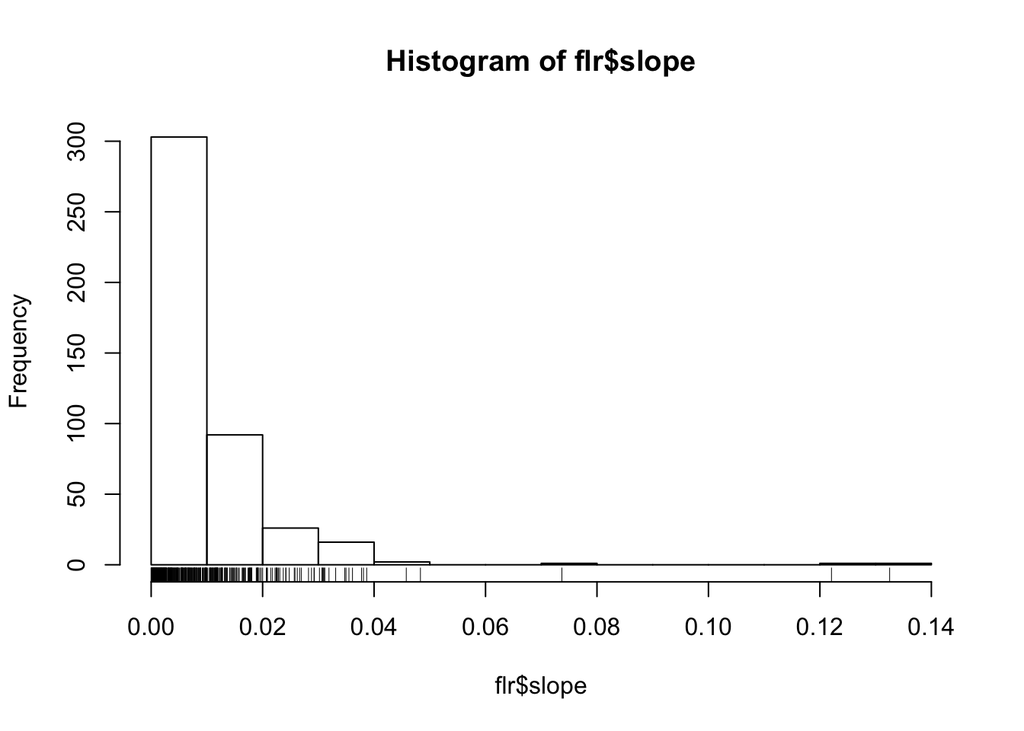

```r
# cleaning data
hist(flr$slope); rug(flr$slope) # look at histogram and rug
```

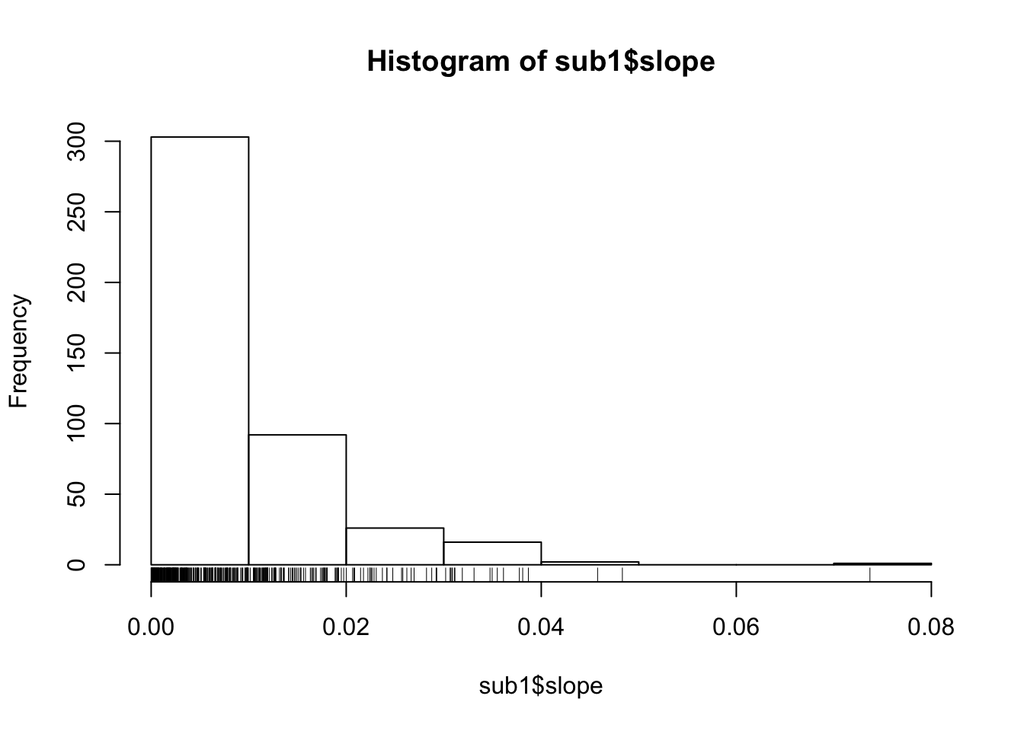

```r
# say we want to drop the points where slope > 0.12
sub1 <- flr[flr$slope < 0.12, ]
hist(sub1$slope); rug(sub1$slope) # check our work
```

#### Calculations within data frames

And tabulating some data from the data frames

```r
# say we want to calculate a new measurement that is a combination of slope + int
flr$NewStat <- flr$slope + flr$int
head(flr$NewStat)
```

```
## [1] 0.04545815 0.08858106 0.10037509 0.14428318 0.23411393 0.18618767
```

```r
# or this will work
flr$NewStat1 <- with(flr, slope + int)
head(flr$NewStat1)
```

```
## [1] 0.04545815 0.08858106 0.10037509 0.14428318 0.23411393 0.18618767
```

```r
# say we want to change one of the variable types in our data frame
class(flr$daysOpen)
```

```
## [1] "integer"
```

```r
flr$daysOpen <- as.factor(flr$daysOpen)
class(flr$daysOpen)
```

```
## [1] "factor"
```

```r
# or this will work
class(flr$flowerNum)
```

```
## [1] "integer"
```

```r
flr <- within(flr, flowerNum <- as.factor(flowerNum))
class(flr$flowerNum)
```

```
## [1] "factor"
```

```r
# calculate averages by individual
# say we want average glycogen for each individual
URL <- "http://nature.berkeley.edu/~casterln/crawley/rats.txt"
rats <- read.csv(URL, sep = "\t")

summary(rats)
```

```
##     Glycogen       Treatment      Rat          Liver
##  Min.   :125.0   Min.   :1   Min.   :1.0   Min.   :1
##  1st Qu.:135.8   1st Qu.:1   1st Qu.:1.0   1st Qu.:1
##  Median :141.0   Median :2   Median :1.5   Median :2
##  Mean   :142.2   Mean   :2   Mean   :1.5   Mean   :2
##  3rd Qu.:150.0   3rd Qu.:3   3rd Qu.:2.0   3rd Qu.:3
##  Max.   :162.0   Max.   :3   Max.   :2.0   Max.   :3
```

```r
tapply(X = rats$Glycogen, FUN = mean, INDEX = rats$Rat)
```

```
##        1        2
## 138.8333 145.6111
```

```r
# calcuate mean by treatment and individual
tapply(X = c(rats$Glycogen), FUN = mean, INDEX = interaction(rats$Rat, rats$Treatment))
```

```
##      1.1      2.1      1.2      2.2      1.3      2.3
## 132.5000 148.5000 149.6667 152.3333 134.3333 136.0000
```

```r
tab1 <- tapply(X = flr$slope, INDEX = flr$trt, FUN = mean)
class(tab1)
```

```
## [1] "array"
```

```r
mode(tab1)
```

```
## [1] "numeric"
```

```r
# tabulate your data (get counts)
xt1 <- xtabs(formula = ~trt, data = flr)
xt1
```

```
## trt
##                            AC           AC and dehumidifier
##                            39                            22
##        AC set to 62 overnight                       Ambient
##                            10                           198
##                  dehumidifier           heat and humidifier
##                            45                            28
## heat and humidifier in alcove     heat set to 80F overnight
##                            32                            36
##                    Humidifier
##                            32
```

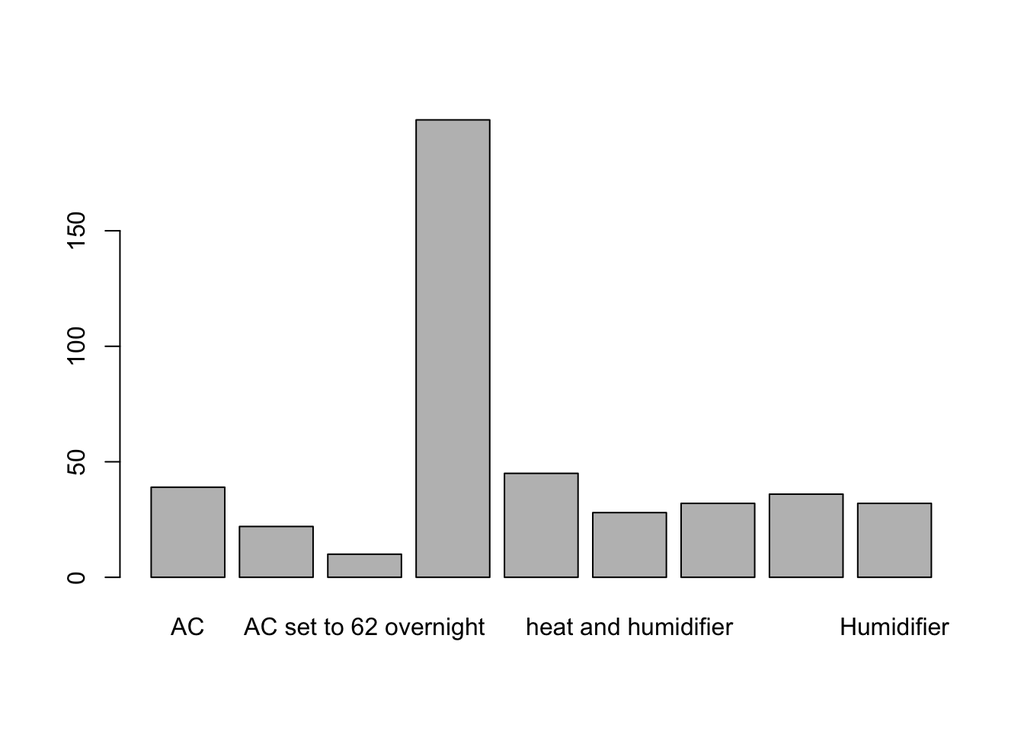

```r
# quickly plot the table
barplot(xt1)
```

```r
# convert to data frame for easy saving
tab1 <- as.data.frame(tab1)
```

Exercises(1, cont’):

### 1.3 Read in the “loblolly.txt” data. Call it “lob”. Make sure header = TRUE, if you use the read.table() function

```r
file.show("datasets/loblolly.txt")
lob <- read.table("datasets/loblolly.txt", header = TRUE, sep = " ")
```

### 1.4 Make a new smaller dataframe, called lob.sm, where “Seed” is not “311”, and where “height” is greater than 5. Plot a histogram of “height” to prove that there are none less than 5 (feel free to add a rug).

- check to see if 311 is in your new dataframe with this command: “311 %in% lob.sm$Seed”

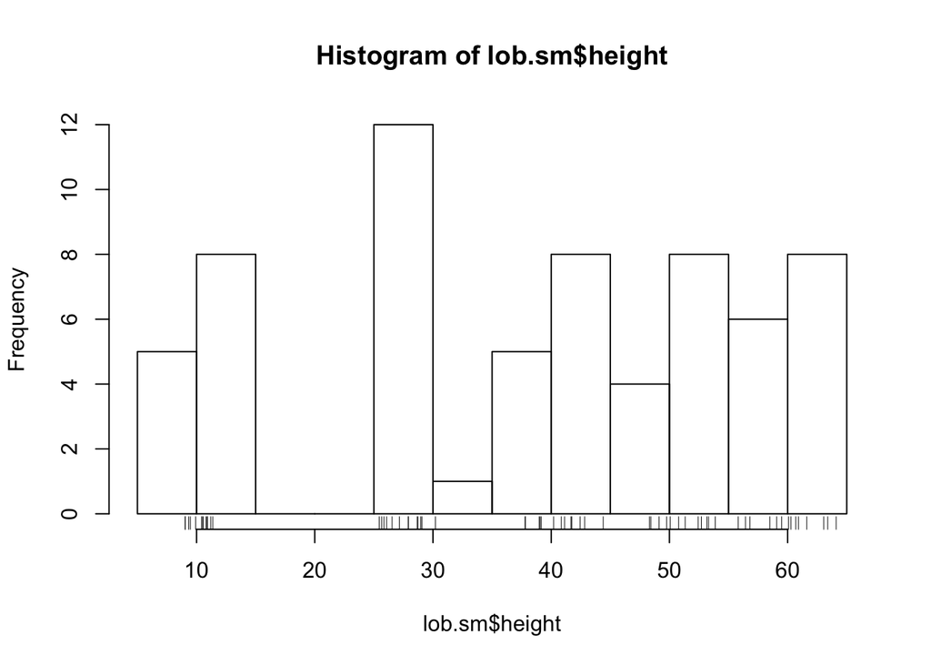

```r
lob.sm <- lob[lob$Seed != 311 & lob$height > 5, ]
hist(lob.sm$height); rug(lob.sm$height)
```

```r
311 %in% lob.sm$Seed # not there
```

```
## [1] FALSE
```

```r
305 %in% lob.sm$Seed # is there
```

```
## [1] TRUE
```

### 1.5 Read in the “yarn.txt” file; call it yarn. Make two separate histograms – one for the breaks in wool A and one for the breaks in wool B.

*Advanced* plot the histograms side-by-side on one panel, and make sure the x-axis limits are the same for each.

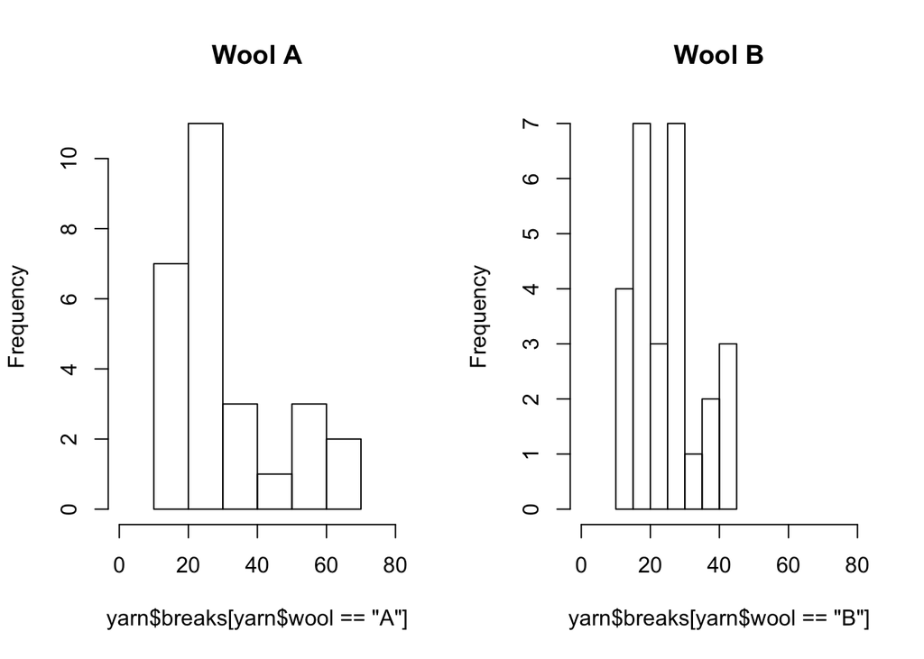

```r
file.show("datasets/yarn.txt")
yarn <- read.table("datasets/yarn.txt", sep = "\t", header = TRUE)

par(mfrow = c(1,2))
limx <- c(0, 80)
hist(yarn$breaks[yarn$wool == "A"], main = "Wool A", xlim = limx)
hist(yarn$breaks[yarn$wool == "B"], main = "Wool B", xlim = limx)
```

```
## stat_bin: binwidth defaulted to range/30. Use 'binwidth = x' to adjust this.
## stat_bin: binwidth defaulted to range/30. Use 'binwidth = x' to adjust this.
```

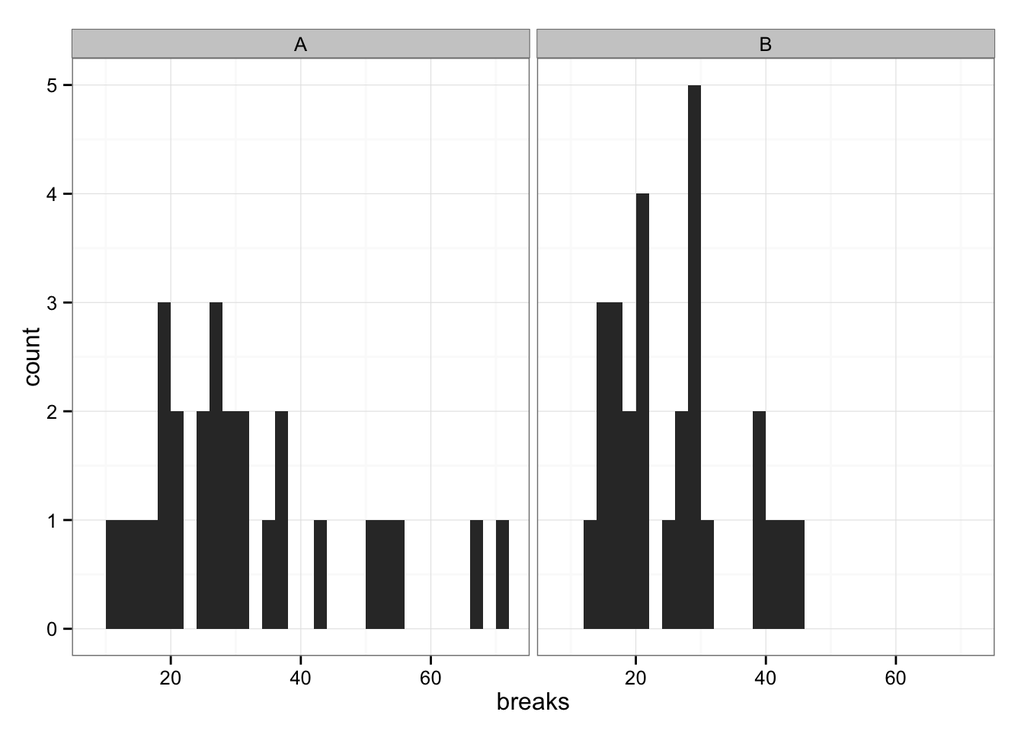

```r
par(mfrow = c(1,1))

## or this
library(ggplot2)
ggplot(yarn, aes(x = breaks)) +
     geom_histogram() +
     facet_wrap( ~ wool) +
     theme_bw()
```

### 1.6 *Advanced* Calculate the mean, median, and range for “breaks” for each type of wool in the dataset.

```r
tapply(yarn$breaks, INDEX = yarn$wool, FUN = function(x) c(mean = mean(x), median = median(x), range = range(x)))
```

```
## $A
##     mean   median   range1   range2
## 31.03704 26.00000 10.00000 70.00000
##
## $B
##     mean   median   range1   range2
## 25.25926 24.00000 13.00000 44.00000
```

## 2. Export data

```r
# Write text files
# can also use write.csv()
tab1
```

```
##                                      tab1
## AC                            0.011855278
## AC and dehumidifier           0.005491899
## AC set to 62 overnight        0.007367714
## Ambient                       0.011548542
## dehumidifier                  0.004839364
## heat and humidifier           0.005158800
## heat and humidifier in alcove 0.003631839
## heat set to 80F overnight     0.003015259
## Humidifier                    0.013709034
```

```r
write.table(x = tab1, file = "Tab1.csv", sep = ",",  col.names = FALSE)
file.remove("Tab1.csv") # remove the file
```

```
## [1] TRUE
```

```r
# saving plots
pdf(file = "plot1.pdf", width = 5, height = 4) # open graphics device
# can also use postscript()
plot(x = flr$humidity, y=flr$temp) # make your plot
dev.off() # close the graphics device
```

```r
# remove the file from my directory
file.remove("plot1.pdf")
```

```
## [1] TRUE
```

```r
# or just export with the "Export" button
```

Exercises(2):

### 2.1 Read int the CallinPollen.txt file (if you haven’t already), and call it flr. Plot x = humidity, y = int. Export this plot to a file called “humInt.pdf”. Make the width = 4 and height = 3.

```r
pdf("humInt.pdf", width = 4, height = 3)
with(flr, plot(x = humidity, y = int))
dev.off()
```

```r
file.remove("humInt.pdf") # remove file
```

```
## [1] TRUE
```

### 2.2 *Advanced* Make that plot look nicer! Change the points to solid dots. Remove the box around the plot. Give it a nice title and rename the axes. Save it with width = 5, height = 4 as “fancyHumInt.pdf”. Note: “int”" is a measurement of pollen released from a flower. (hint: type “?plot” to see help)

```r
pdf("fancyHumInt.pdf", width = 5, height = 4)
with(flr, plot(x = jitter(humidity), y = int,
               ylab = "Pollen (Integration Method)",
               xlab = "Relative Humidity (%)",
               bty = "l",
               main = "Pollen released vs. Humidity",
               pch = 20,
               col = rgb(.9, .5, .3, .9)
               ))
dev.off()
```

```r
file.remove("fancyHumInt.pdf")
```

```
## [1] TRUE
```

### 2.3 Subset the flr dataset to contain only rows where “distance” > 9 & the “distance” variable is not an “NA” (hint: use !is.na()). Call the new data frame flr.dist. Export this small data frame as “flrDist.csv”.

```r
flr.dist <- flr[flr$distance > 9 & !is.na(flr$distance), ]
write.csv(flr.dist, file = "flrDist.csv")
file.remove("flrDist.csv") # remove
```

```
## [1] TRUE
```

## 3 Formatting data and visualization using ggplot()

Review: installing new libraries

use install.packages(“…”), but you only ned to use this the first time you use the library. After that, you can just use library(“…”)

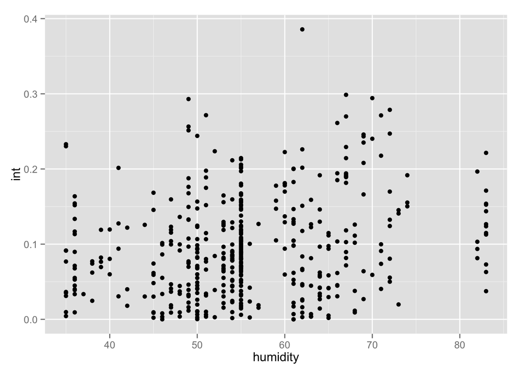

```r
# install.packages("ggplot2") # do this only the first time you use a library
library(ggplot2) # now, this package is ready to use
# help(package = "ggplot2") # gets help for this new package or library


# let's try it
ggplot(flr, aes(x= humidity, y = int)) +
     geom_point()
```

Exercises(3):

### 3.1 Load the ggplot2 library (install, if you haven’t already).

### 3.2 To make sure it works, type the following:

ggplot(flr, aes(x = temp, y = humidity)) + geom_point()

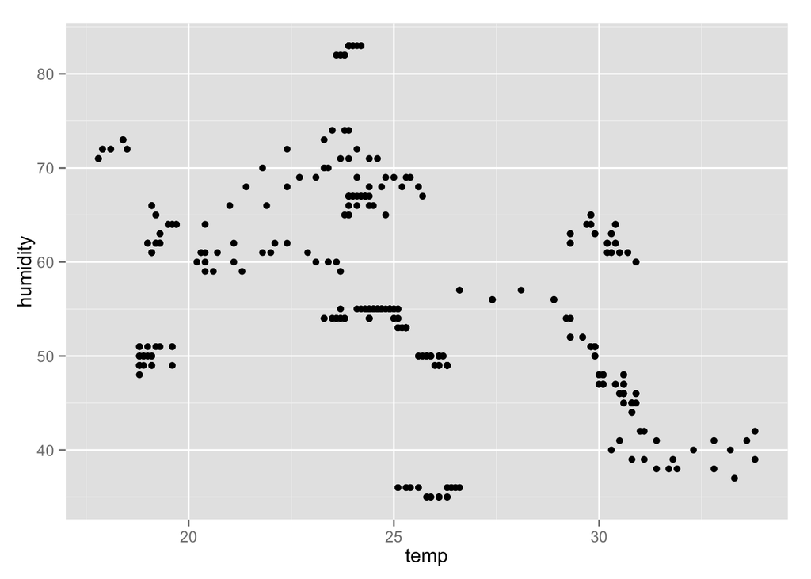

```r
ggplot(flr, aes(x = temp, y = humidity)) +
     geom_point()
```

#### Ways to format data for ggplot

```r
df1 <- data.frame(person = c("bob", "sue", "jack", "ann"), number1 = c(4,5,6,1), number2 = c(2,4,6,6))
df1
```

```
##   person number1 number2
## 1    bob       4       2
## 2    sue       5       4
## 3   jack       6       6
## 4    ann       1       6
```

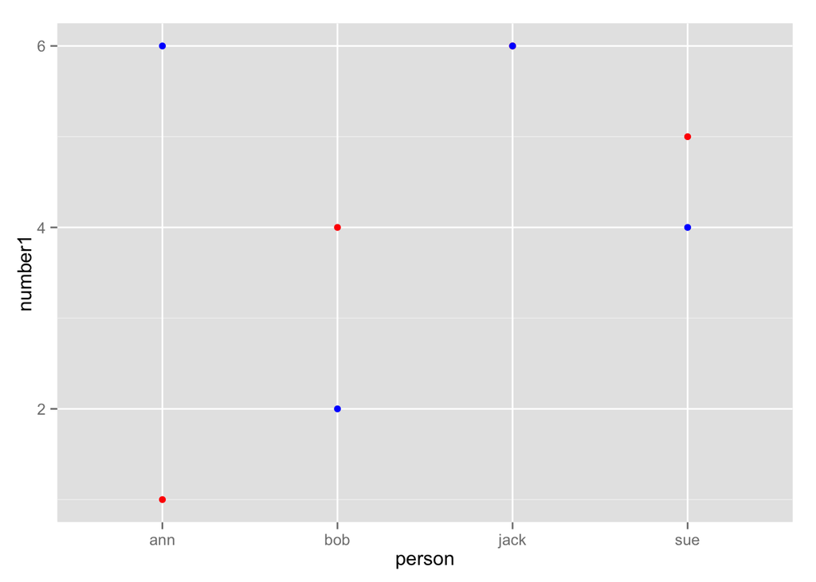

```r
# we want to plot persons' number1 and number2, but we'd need them to be in the same column
# wrong
ggplot(df1) +
     geom_point(aes(x = person, y = number1), color = "red") +
     geom_point(aes(x = person, y = number2), color = "blue")
```

```r
# you can reformat
library(reshape2)
df.melt <- melt(df1, id.vars = "person")
head(df.melt)
```

```
##   person variable value
## 1    bob  number1     4
## 2    sue  number1     5
## 3   jack  number1     6
## 4    ann  number1     1
## 5    bob  number2     2
## 6    sue  number2     4
```

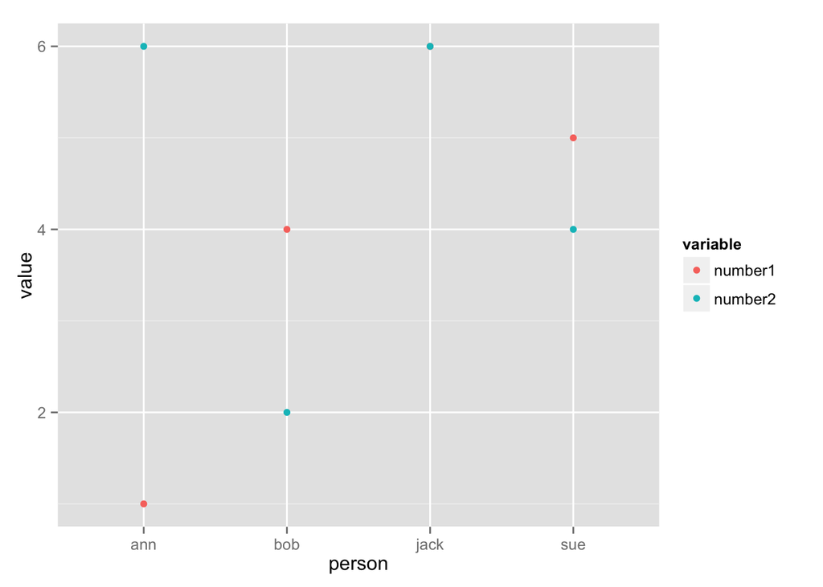

```r
ggplot(df.melt, aes(x = person, y = value)) +
     geom_point(aes(color = variable))
```

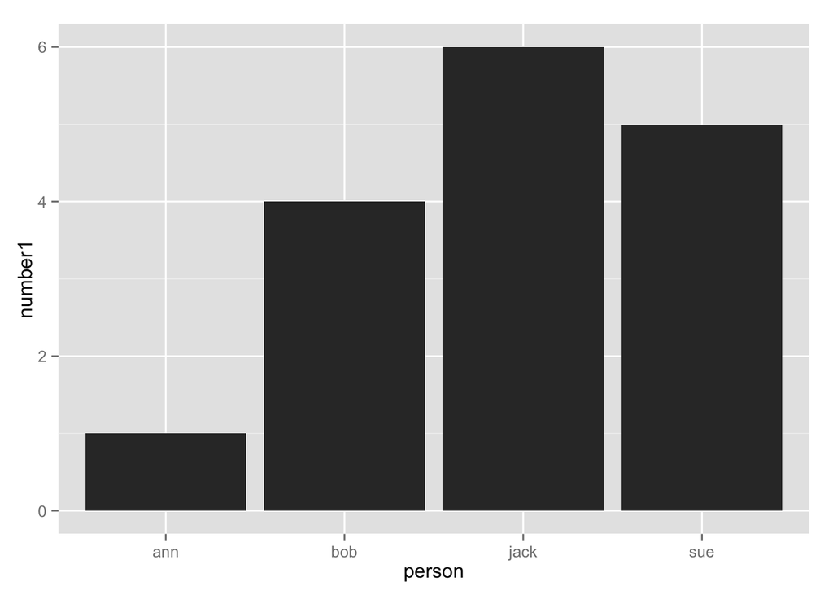

```r
## formatting for barcharts
ggplot(df1, aes(x = person, y = number1)) +
     geom_bar(stat = "identity")
```

```r
## or reshape the data frame
df.long <- data.frame(person = unlist(sapply(as.character(df1$person),
                                             FUN = function(x)
                                                  rep(x, times = df1[df1$person == x, "number1"]))))

head(df.long)
```

```
##      person
## bob1    bob
## bob2    bob
## bob3    bob
## bob4    bob
## sue1    sue
## sue2    sue
```

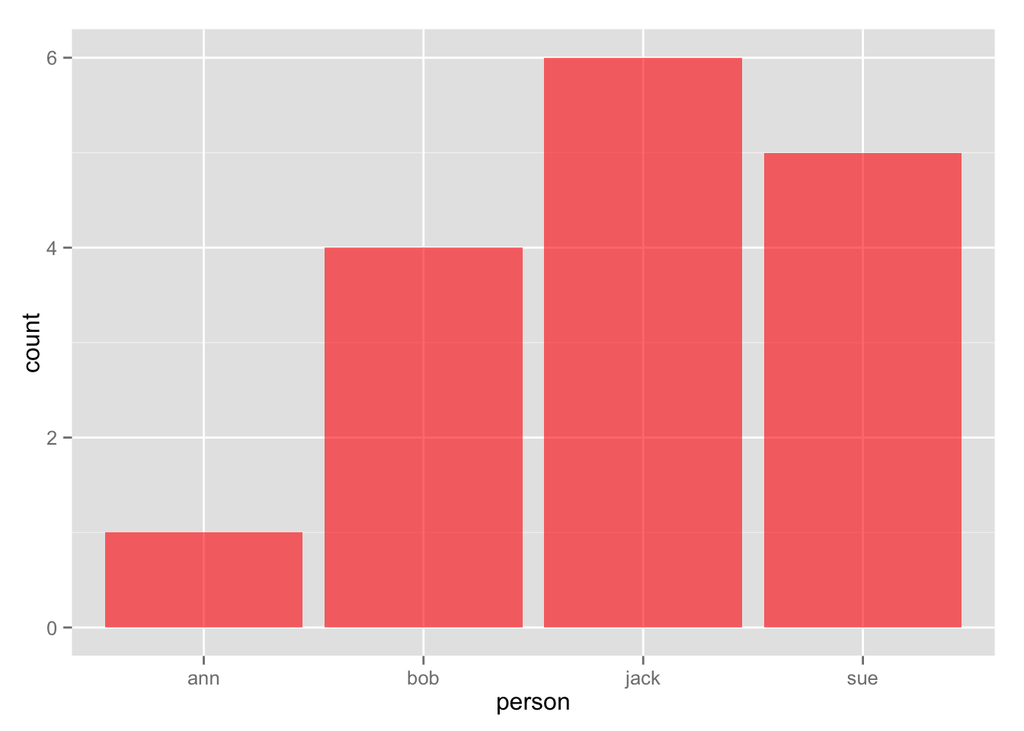

```r
ggplot(df.long, aes(x = person)) +
     geom_bar( fill = "red", alpha = 0.6)
```